# Investigating the prescription change of Gaviscon over the winter holidays in Scotland

Orianne Slater

Nov-2024

## Introduction

Heartburn is a pain in the chest felt when acid from the stomach travels up the oesophagus. This can happen as a result of different factors including smoking, being overweight, consumption of certain food, alcohol consumption, and stress. To aliviate heartburn, Gaviscon can be administered. Using data on monthly prescribed medication, this study will investigate the change in Gaviscon prescription during the winter holidays. December, with the festivities, is a month well associated with the over consumption of food and alcohol whereas January has associations of wellness and new starts. This might suggest that Gaviscon use would be higher during December compared to January.

## Loading Libraries

```r
library(tidyverse)
library(janitor) #clean data
library(here) #locate data
library(gt) #tables
```

## Loading Data

```r
#creating a list of the files containing prescription data
files <- list.files(here("data"), pattern = "20")

#creating a dataframe which combines all of the information in the files and cleaning the column names for consistency
all_data <- files %>%
  map_dfr(~read_csv(here("data", .))) %>%
  clean_names() %>%
  mutate(hb = coalesce(hbt, hbt2014))

#loading in data for healthboard names and cleaning the column names for consistency
hb <- read_csv(here("data", "health_boards.csv")) %>%
  clean_names()

#joining precription data to healthboard names
hb_and_prescription <- all_data %>%
  full_join(hb, by = c("hb" = "hb"))

#loading in data for education level of healthboard
education_levels <- read_csv(here("data", "table_2024-11-22_21-18-31.csv"), skip = 10) %>%
  clean_names()
```

## Wrangling Data

```r
#The data must be wrangled in order to make it easier to use later.
combined_scotland_data  <- hb_and_prescription %>%
  mutate(paid_date_month = parse_date_time(paid_date_month, "ym")) %>%
  mutate(year = format(paid_date_month, "%Y"))

#creating a function for the creation of columns needed
dates_func <- function(df) {
  df %>%
  mutate(holiday = case_when(month(paid_date_month) == 12 ~ paste(year(paid_date_month), year(paid_date_month) + 1, sep = "/"),
                             month(paid_date_month) == 1 ~ paste(year(paid_date_month) - 1, year(paid_date_month), sep = "/"))) %>%
  mutate(month = month(paid_date_month, label = TRUE, abbr = FALSE))
}

for_plot <- combined_scotland_data %>%
  filter(str_detect(bnf_item_description, "GAVISCON")) %>%
  group_by(paid_date_month) %>%
  summarise(paid_quantity = sum(paid_quantity)) %>%
  dates_func()
```

## Plotting Data

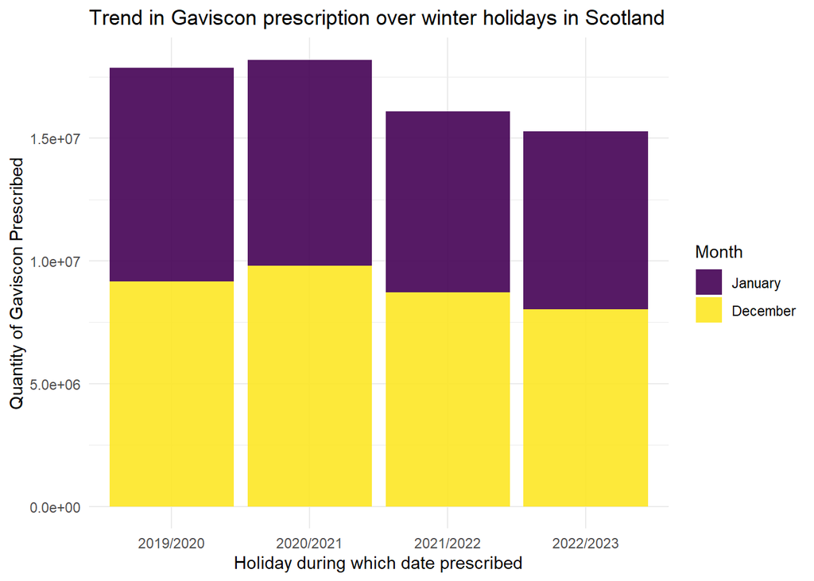

```r
#plotting data
gaviscon <- for_plot %>%
  ggplot(aes(x = holiday, y = paid_quantity, fill = month))+
  geom_bar(stat = "identity", alpha = 0.9)+
 # facet_wrap(~HBName)
  theme_minimal()+
  labs(x = "Holiday during which date prescribed",
       y = "Quantity of Gaviscon Prescribed",
       title = "Trend in Gaviscon prescription over winter holidays in Scotland",
       fill = "Month")
gaviscon
```

## Comparison of differences between December and January

```r
#making table to compare differences observed
change_in_prescription <- for_plot %>%
  select(holiday, paid_quantity, month) %>%
  pivot_wider(names_from = month, values_from = paid_quantity) %>%
  mutate(difference = January - December) %>%
  mutate(percent = difference/December)

change_table <- change_in_prescription %>%
  gt() %>%
  fmt_number(columns = c(December, January, difference), decimals = 0) %>%
  fmt_percent(columns = percent, decimals = 2) %>%
  tab_header(title = "Prescription Quantity of Gaviscon During Winter Holidays",
             subtitle = "Data from NHS Scotland") %>%
  cols_label(holiday = " ",
             difference = "Change",
             percent = "Percentage Change") %>%
  cols_align(align = "center",
              columns = percent)
change_table
```

Prescription Quantity of Gaviscon During Winter Holidays

Data from NHS Scotland

|  | December | January | Change | Percentage Change |
| --- | --- | --- | --- | --- |
| 2019/2020 | 9,171,039 | 8,711,055 | −459,984 | −5.02% |
| 2020/2021 | 9,811,769 | 8,390,883 | −1,420,886 | −14.48% |
| 2021/2022 | 8,713,855 | 7,382,644 | −1,331,211 | −15.28% |
| 2022/2023 | 8,027,304 | 7,267,184 | −760,120 | −9.47% |

## Assessing trends in all prescriptions

In order to check whether the decrease in Gaviscon prescription is possibly affected by social/celebrations and then new year new me xx, the general trend of all presriptions in the months of December and January will be assessed for a difference.

```r
all_prescriptions <- combined_scotland_data %>%
  filter(!is.na(bnf_item_description)) %>%
  group_by(paid_date_month) %>%
  summarise(paid_quantity = sum(paid_quantity)) %>%
  dates_func() %>%
  select(holiday, paid_quantity, month) %>%
  pivot_wider(names_from = month, values_from = paid_quantity) %>%
  mutate(difference = January - December) %>%
  mutate(percent = difference/December)

general_trend <- all_prescriptions %>%
  gt() %>%
  fmt_number(columns = c(December, January, difference), decimals = 0) %>%
  fmt_percent(columns = percent, decimals = 2) %>%
  tab_header(title = "Prescription Quantity During Winter Holidays",
             subtitle = "Data from NHS Scotland") %>%
  cols_label(holiday = " ",
             difference = "Change",
             percent = "Percentage Change") %>%
  cols_align(align = "center",
              columns = percent)
general_trend
```

Prescription Quantity During Winter Holidays

Data from NHS Scotland

|  | December | January | Change | Percentage Change |
| --- | --- | --- | --- | --- |
| 2019/2020 | 643,944,294 | 620,397,315 | −23,546,978 | −3.66% |
| 2020/2021 | 672,505,390 | 583,051,847 | −89,453,543 | −13.30% |
| 2021/2022 | 677,482,833 | 590,962,579 | −86,520,254 | −12.77% |
| 2022/2023 | 661,109,487 | 618,065,973 | −43,043,514 | −6.51% |

## Investigating the differences between healthboards

```r
cleaning_edu <- education_levels %>%
  slice(1:15) %>%
  filter(!is.na(highest_level_of_qualification)) %>%
  filter(!is.na(all_people_aged_16_and_over)) %>%
  mutate(all_people = as.numeric(all_people_aged_16_and_over)) %>%
  mutate(proportion = no_qualifications/all_people) %>%
  mutate(hb_name = paste("NHS", highest_level_of_qualification))

gaviscon_by_hb <- combined_scotland_data %>%
  filter(str_detect(bnf_item_description, "GAVISCON")) %>%
  dates_func() %>%
  group_by(hb_name, month) %>%
  summarise(paid_quantity = sum(paid_quantity)) %>%
  pivot_wider(names_from = month, values_from = paid_quantity) %>%
  mutate(average_diff = (January - December)/4)
gaviscon_and_education <- gaviscon_by_hb %>%
  full_join(cleaning_edu) %>%
  mutate(gaviscon_proportion = average_diff/all_people)
```

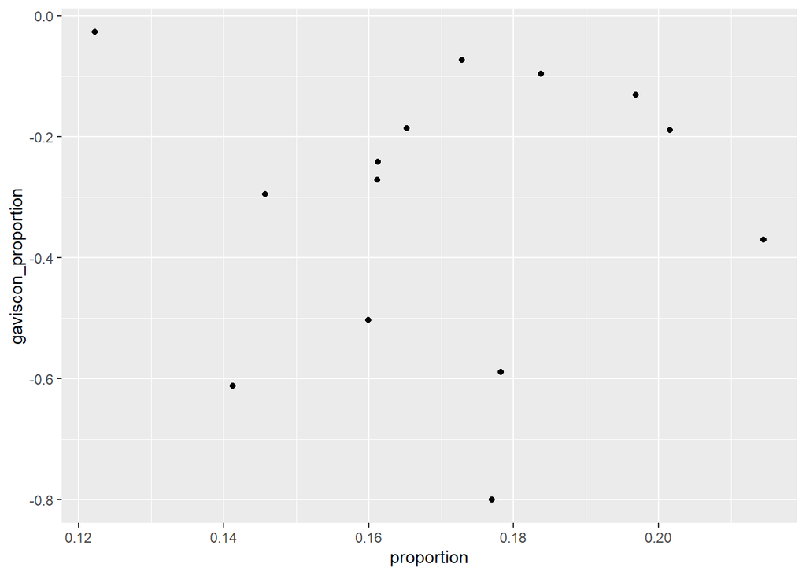

```r
hb_gav_plot <- gaviscon_and_education %>%
  ggplot(aes(x = proportion, y = gaviscon_proportion))+
  geom_point()
hb_gav_plot
```

to do:

- change names
- use healthboard data
- clear justifications with relevant references
- limitations and next steps
- use census for socioeconomics and whether that effects the proportion of change? (difference/initial)
- look into general trend for decrease in precriptions in Jan
- check omeprazole or other antacids